# DETECTR 044 Luminometer Data with ENLITEN Kit

Note that everything is plotted on a log10(x) and flexible log10(y) scale, meaning the axis changes with every plot. Background ENLITEN RFU values seems to drop over time. Experiments are presented in the order performed. All reads had a 2s delay and 10s integration time, unlike the desired 60s integration because the instrument maximum was 10s. Though I thought that the injectors would inject both reagents at the same time, they in fact inject 1, take a read, and then inject 2, and take a read. For the AMP GLO kit, (by mistake, because it was set up based on assumption it would inject simaltaneously), ENLITEN was added first, then AMP. This was corrected for UMP GLO kit, so UMP went first and ENLITEN went second. All moles are in 100uL, so 1e-10 is 1uM, etc.

### Experiment groupings and order

1. ENLITEN Standards
2. AMP 0hr incubation, ENLITEN and then AMP injected at 0hr timepoint
3. UMP 0hr incubation, UMP and then ENLITEN injected at 0hr timepoint
4. AMP, UMP, and AMP no Kinase GLO 1 hr incubate, then ENLITEN injected at 1hr timepoint in all

## ENLITEN ATP Standards from 1E-11 to 1E-17 moles

- in 100uL with 10s integration
- Welsh 2-sided T-Test (unequal variance, unpaired) performed between 1E-11 and 0, 1E-16 and 0, and then 1E-17 and 0
- Highest concentration well was read first
- 1E-18 added to 0 moles to allow for plotting on log scale
- 0 point removed for logistic regression plotted on log scale

### Conclusion

Difference between 1E-16 luminescence and 0 is significant, but 1E-17 difference is not. I would say that if technical replicates are performed we can detect down to 1E-16 but not further. Relationship is fit well with linear regression based on R2, on all concentrations and low concentrations, but residuals don’t look great. Might be worth investigating another fit.

```
##
##  Welch Two Sample t-test
##
## data:  subset(standard_044, concentration_moles %in% c(0, 1e-11))$rfu_value by subset(standard_044, concentration_moles %in% c(0, 1e-11))$concentration_moles
## t = -53.581, df = 2.0001, p-value = 0.000348
## alternative hypothesis: true difference in means is not equal to 0
## 95 percent confidence interval:
##  -16682600 -14202585
## sample estimates:
##     mean in group 0 mean in group 1e-11
##            78207.77         15520800.00
```

```
##
##  Welch Two Sample t-test
##
## data:  subset(standard_044, concentration_moles %in% c(0, 1e-16))$rfu_value by subset(standard_044, concentration_moles %in% c(0, 1e-16))$concentration_moles
## t = -4.7002, df = 2.9292, p-value = 0.01921
## alternative hypothesis: true difference in means is not equal to 0
## 95 percent confidence interval:
##  -25645.110  -4768.157
## sample estimates:
##     mean in group 0 mean in group 1e-16
##            78207.77            93414.40
```

```
##
##  Welch Two Sample t-test
##
## data:  subset(standard_044, concentration_moles %in% c(0, 1e-17))$rfu_value by subset(standard_044, concentration_moles %in% c(0, 1e-17))$concentration_moles
## t = -1.7638, df = 2.8468, p-value = 0.1809
## alternative hypothesis: true difference in means is not equal to 0
## 95 percent confidence interval:
##  -17023.114   5120.914
## sample estimates:
##     mean in group 0 mean in group 1e-17
##            78207.77            84158.87
```

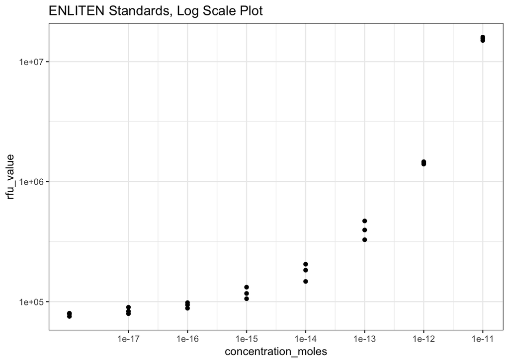

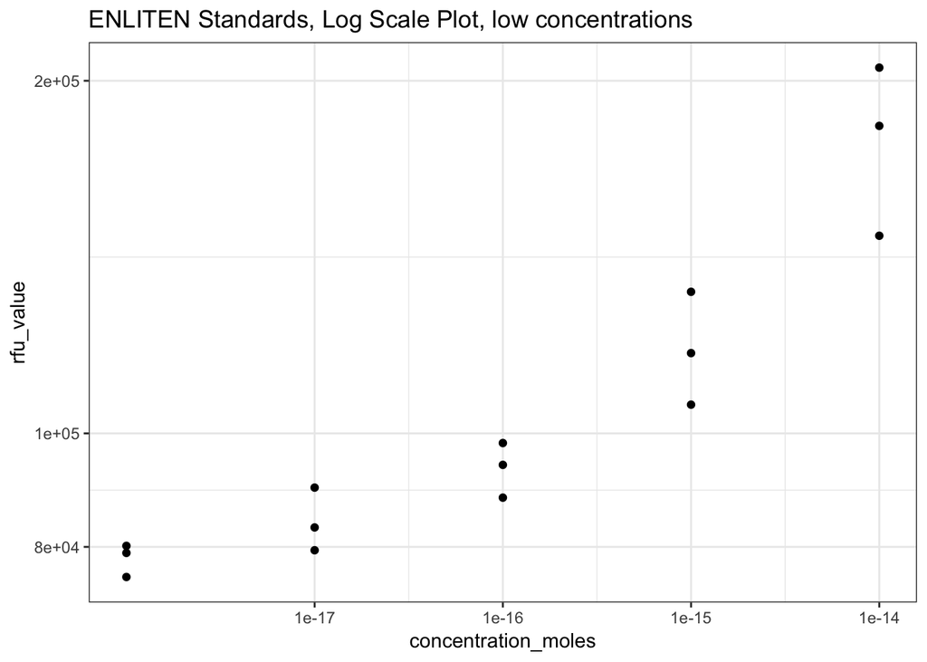

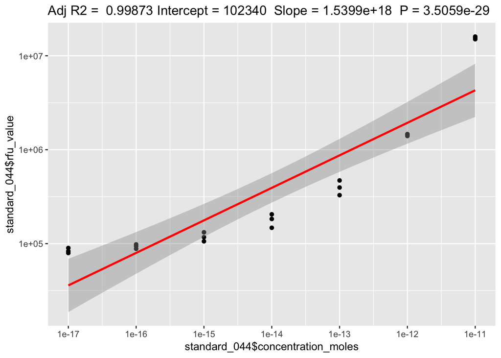

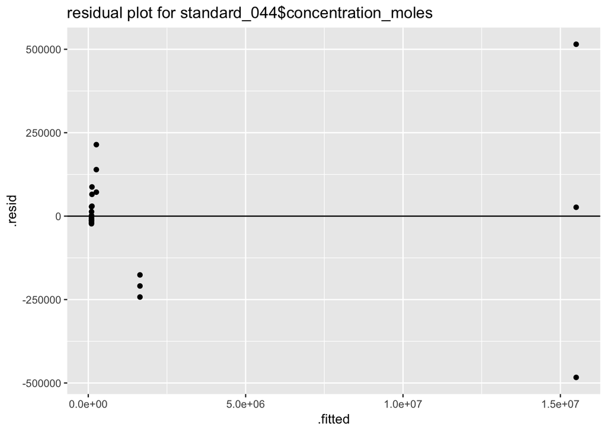

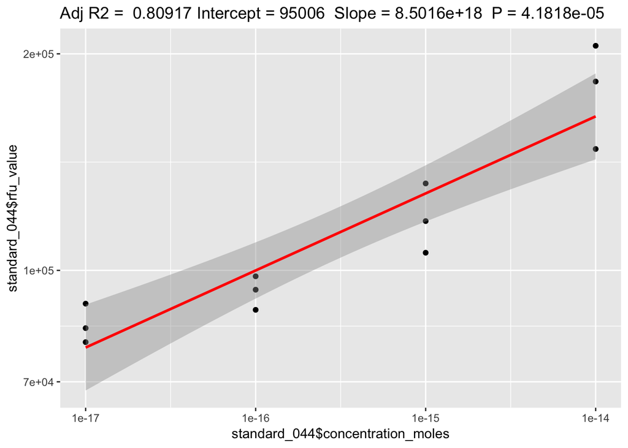

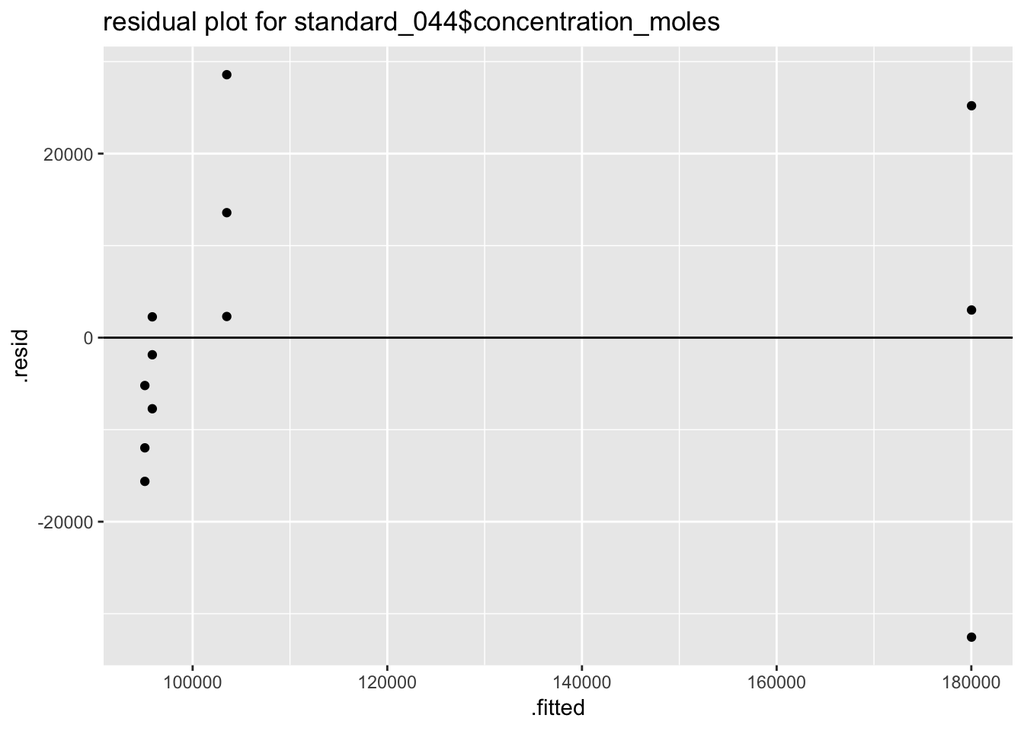

## ENLITEN ATP Standards from 1E-11 to 1E-17 moles (60s read)

- in 100uL with 10s integration, 6 reads with no spacing between them - total of 60s read
- Welsh 2-sided T-Test (unequal variance, unpaired) performed between 1E-11 and 0, 1E-12 and 0, 1E-16 and 0, and then 1E-17 and 0
- Highest concentration well was read first
- 1E-18 added to 0 moles to allow for plotting on log scale
- 0 point removed for logistic regression plotted on log scale

### Conclusion

Difference between (1E-17 luminescence and 0) and (1E-16 luminescence and 0) is significant, but 1E-11 difference is not due, presumably because of high variance. We may be able to go below 1E-17 based on this data. Relationship is not fit well with linear regression based on R2 and residuals on all concentrations but looks great for low concentrations. Concentration doesn’t really look like it drops off that much over the course of a minute, which is contrary to what I would expect (see second to last plot). The largest differences for high concentrations are between the replicates (see last plot)

```
##
##  Welch Two Sample t-test
##
## data:  subset(standard_044_sum, concentration_moles %in% c(0, 1e-11))$rfu_value by subset(standard_044_sum, concentration_moles %in% c(0, 1e-11))$concentration_moles
## t = -2.7498, df = 2, p-value = 0.1107
## alternative hypothesis: true difference in means is not equal to 0
## 95 percent confidence interval:
##  -443235339   97595543
## sample estimates:
##     mean in group 0 mean in group 1e-11
##             1489902           174309800
```

```
##
##  Welch Two Sample t-test
##
## data:  subset(standard_044_sum, concentration_moles %in% c(0, 1e-12))$rfu_value by subset(standard_044_sum, concentration_moles %in% c(0, 1e-12))$concentration_moles
## t = -23.111, df = 2.0001, p-value = 0.001867
## alternative hypothesis: true difference in means is not equal to 0
## 95 percent confidence interval:
##  -10371419  -7115871
## sample estimates:
##     mean in group 0 mean in group 1e-12
##             1489902            10233547
```

```
##
##  Welch Two Sample t-test
##
## data:  subset(standard_044_sum, concentration_moles %in% c(0, 1e-16))$rfu_value by subset(standard_044_sum, concentration_moles %in% c(0, 1e-16))$concentration_moles
## t = -63.775, df = 3.9085, p-value = 4.8e-07
## alternative hypothesis: true difference in means is not equal to 0
## 95 percent confidence interval:
##  -190293.9 -174274.8
## sample estimates:
##     mean in group 0 mean in group 1e-16
##             1489902             1672186
```

```
##
##  Welch Two Sample t-test
##
## data:  subset(standard_044_sum, concentration_moles %in% c(0, 1e-17))$rfu_value by subset(standard_044_sum, concentration_moles %in% c(0, 1e-17))$concentration_moles
## t = -12.024, df = 2.4844, p-value = 0.002898
## alternative hypothesis: true difference in means is not equal to 0
## 95 percent confidence interval:
##  -87785.8 -47412.2
## sample estimates:
##     mean in group 0 mean in group 1e-17
##             1489902             1557501
```

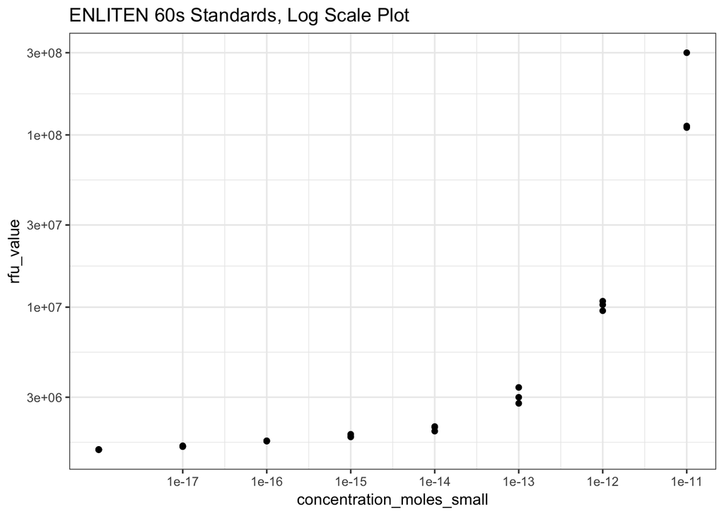

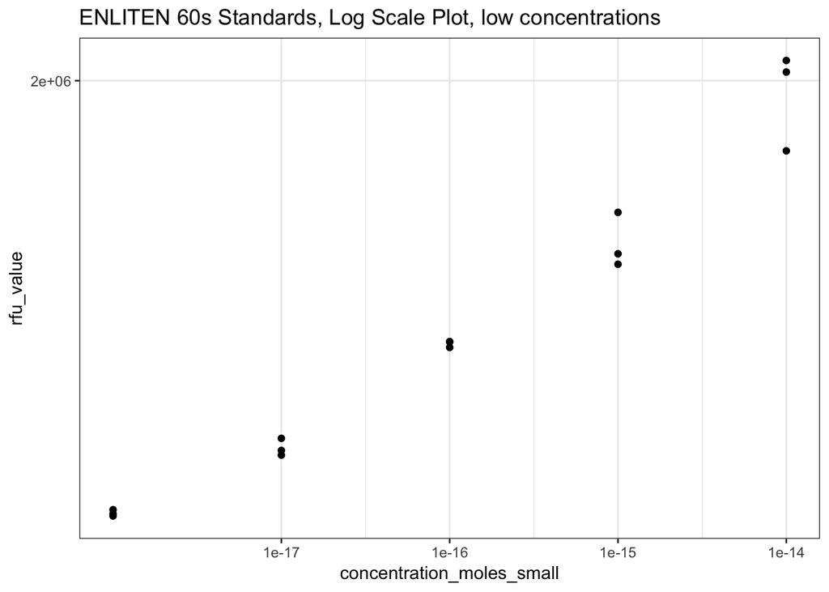

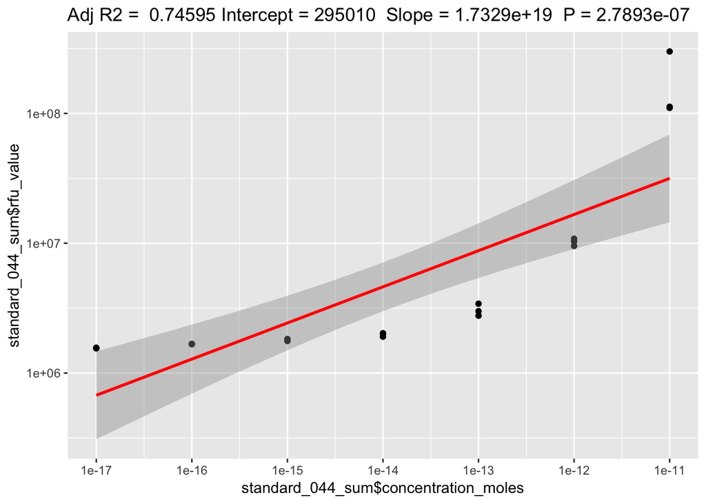

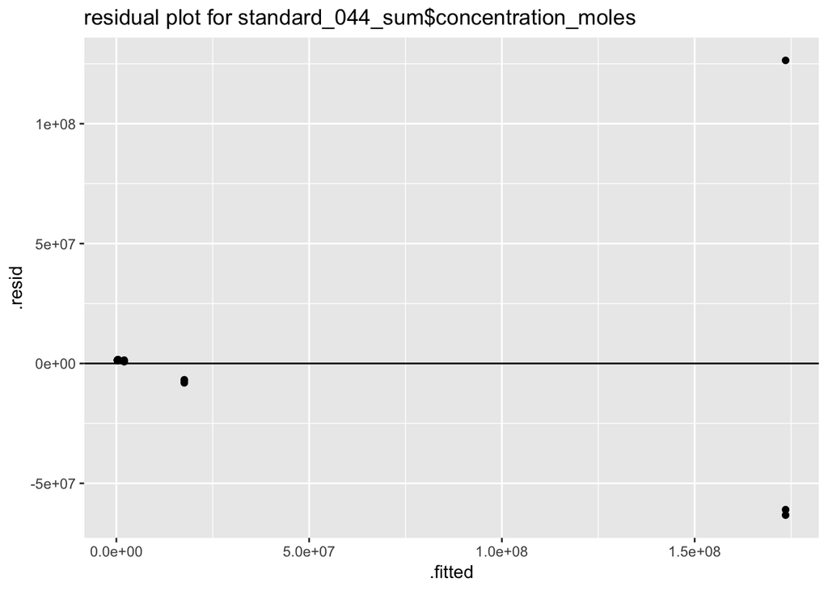

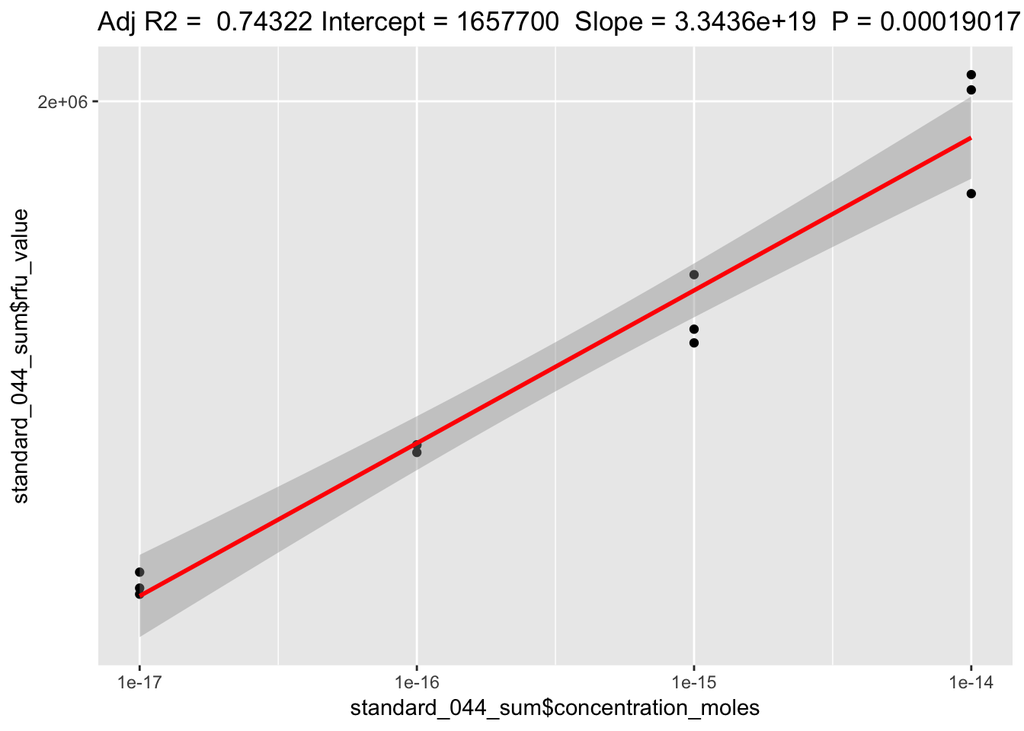

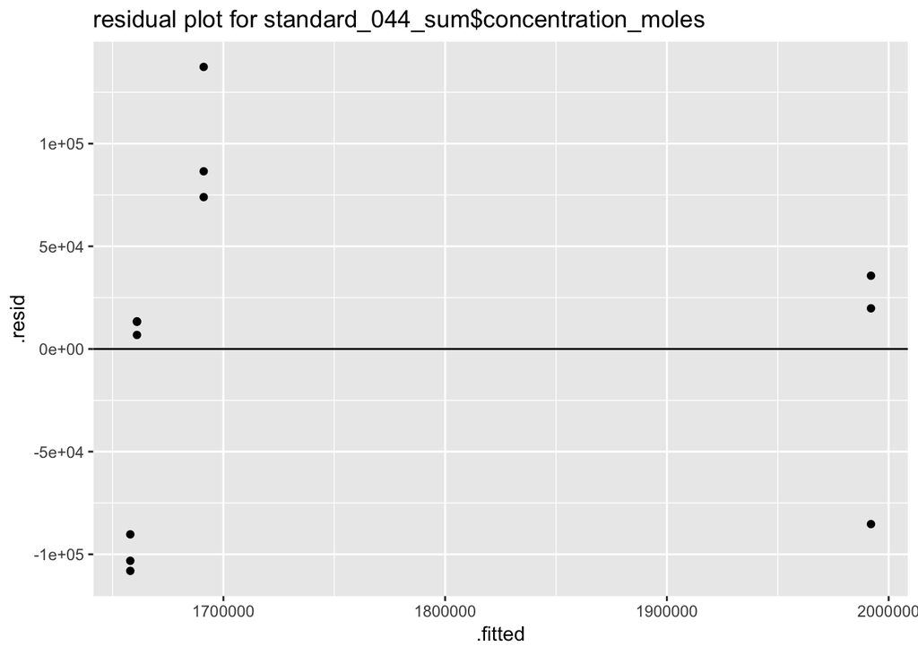

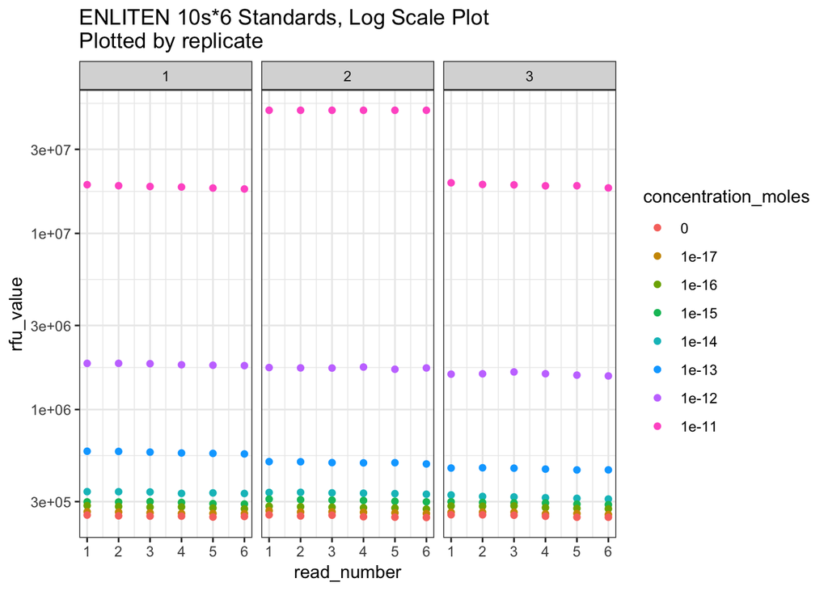

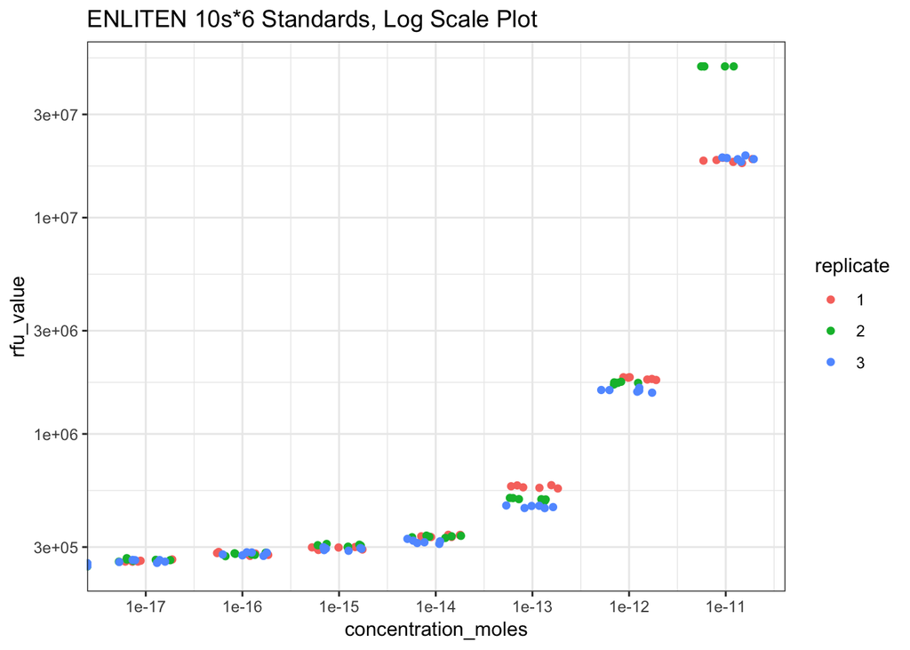

## AMP GLO 0 hr injection

- ENLITEN Kit was injected first, a 2s delay followed by 10 s read was taken, AMP GLO kit was injected, a 2s delay followed by 10 s read was taken
- A reading of the whole plate was taken after all injections had been performed (~5 minutes later for the first sample)
- Highest concentration well was read first
- 1E-17 added to 0 moles to allow for plotting on log scale

### Conclusions

When ENLITEN was injected, no ADP had been converted to ATP. Once AMP was added, it seems like there was a signal boost which had the same curve as the ENLITEN kit. The baseline after ENLITEN could just be a background increase, or it could be whatever ATP was already in the solution. The signal increase after AMP could also be a background signal or it could be the AMP reacting with whatever ATP is already in solution. After the initial burst, signal was incredibly low, indicating that the ENLITEN signal had died off. These are some pretty weird curves - something else is probably going on too. I’m not sure why it goes down in the middle concentrations during the injector steps, while at the endpoint read, it goes up.

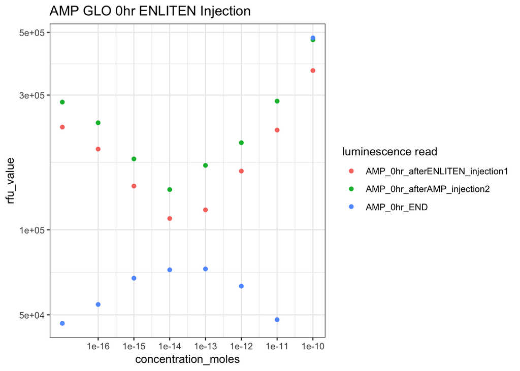

## UMP GLO 0 hr injection

- UMP Kit was injected first, a 2s delay followed by 10 s read was taken, ENLITEN kit was injected, a 2s delay followed by 10 s read was taken
- Highest concentration well was read first
- 1E-17 added to 0 moles to allow for plotting on log scale

### Conclusion

This experiment shows similar curve to AMP GLO 0hr experiment, even though the reagents were injected in a different order. This makes it seem likely that whatever is going on is either a background signal or a reaction with ATP already present in solution. Not sure why the signal is lower in the middle concentrations again…

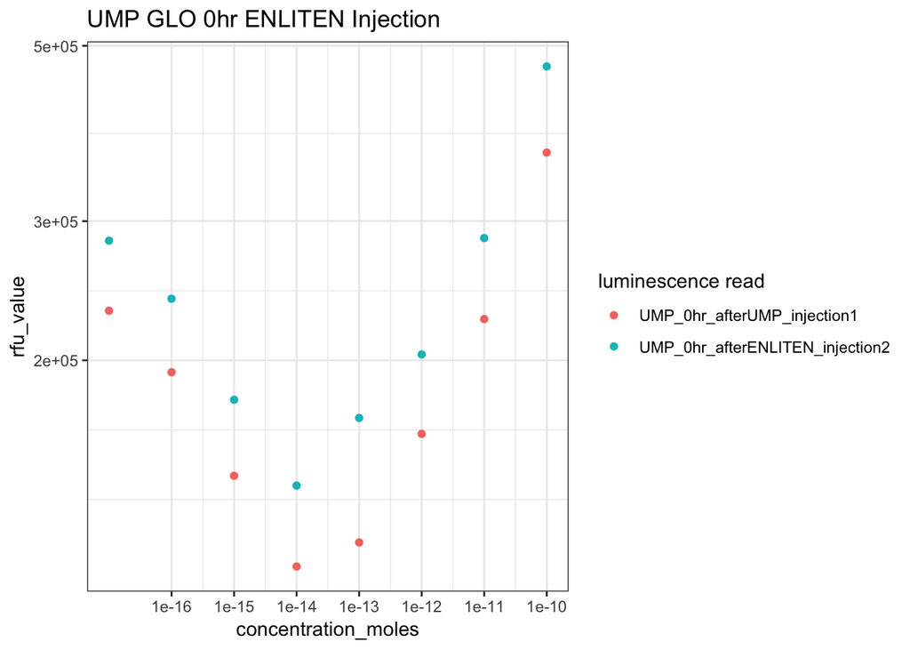

## AMP GLO 1hr incubation + ENLITEN Kit

- AMP GLO kit was added to AMP standards and read was taken. This is the 1hr_START read.
- Read was taken during room temperature incubation at 25 minutes and 45 minutes
- At 50 minutes, injection read was performed - starting with highest concentration, ENLITEN was injected, a 2s delay occured and a 10s read was taken. This is the 1hr_END read.

### Conclusion

Limit of detection (1e-12, or 0.01uM) is close with AMP GLO kit (~0.04uM) but is slightly improved. To me this indicates ENLITEN is contributing to sensitivity but likely by at most an order of magnitude. Signal seems to go up over time for high concentrations, consistent with AMP GLO kits, and drop off slightly for lower concentrations. When ENLITEN is added, for all concentrations, a certain background is added that is roughly proportional to signal (ie more signal is added for higher concentrations). My hypothesis is that there is not enough ATP in the lower concentration samples and that it is being digested by AMP luciferase.

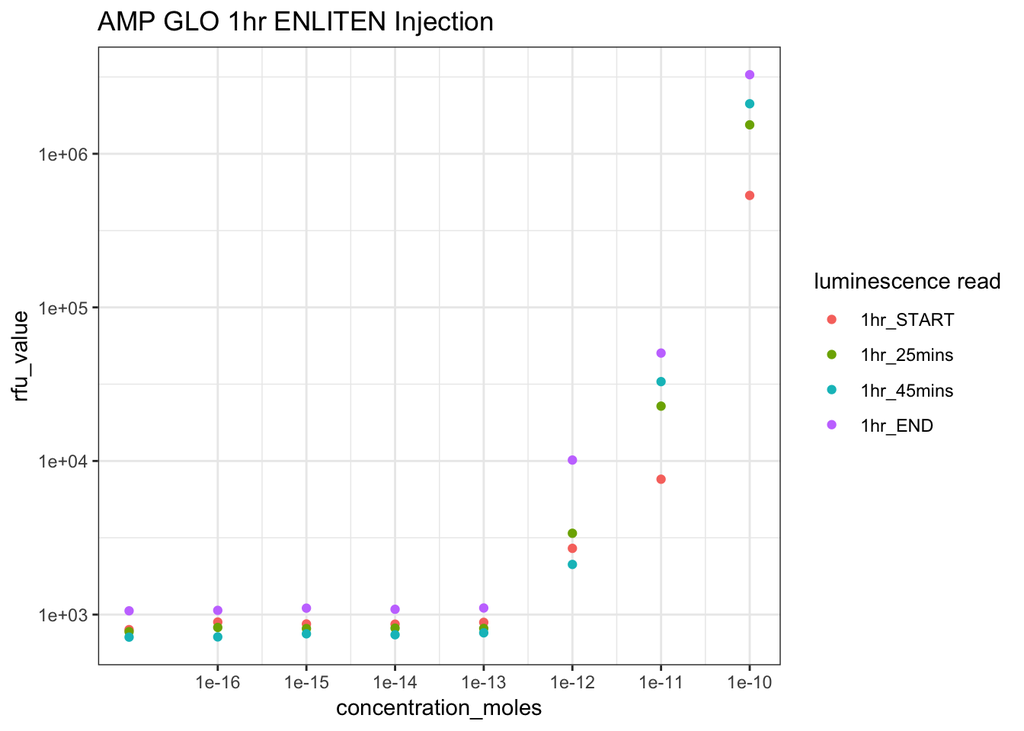

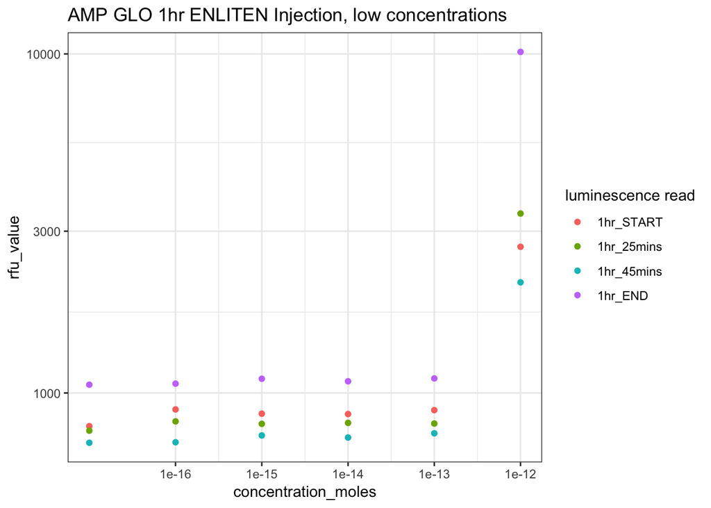

## UMP GLO 1hr incubation + ENLITEN Kit

- UMP GLO kit was added to AMP standards and read was taken. This is the 1hr_START read.
- Read was taken during room temperature incubation at 25 minutes and 45 minutes
- At 50 minutes, injection read was performed - starting with highest concentration, ENLITEN was injected, a 2s delay occured and a 10s read was taken. This is the 1hr_END read.

### Conclusions

This is similar to the AMP GLO experiment, except it seems less sensitive than AMP GLO (down to 1e-11). UMP GLO doesn’t act as fast as the AMP GLO kit (starting luciferase is not correlated with concentration), though there was a 1min longer incubation for the AMP GLO reagents. This kit might get to AMP GLO sensitivity in the same protocol if we did perform technical replicates, since this is more sensitive to noise.

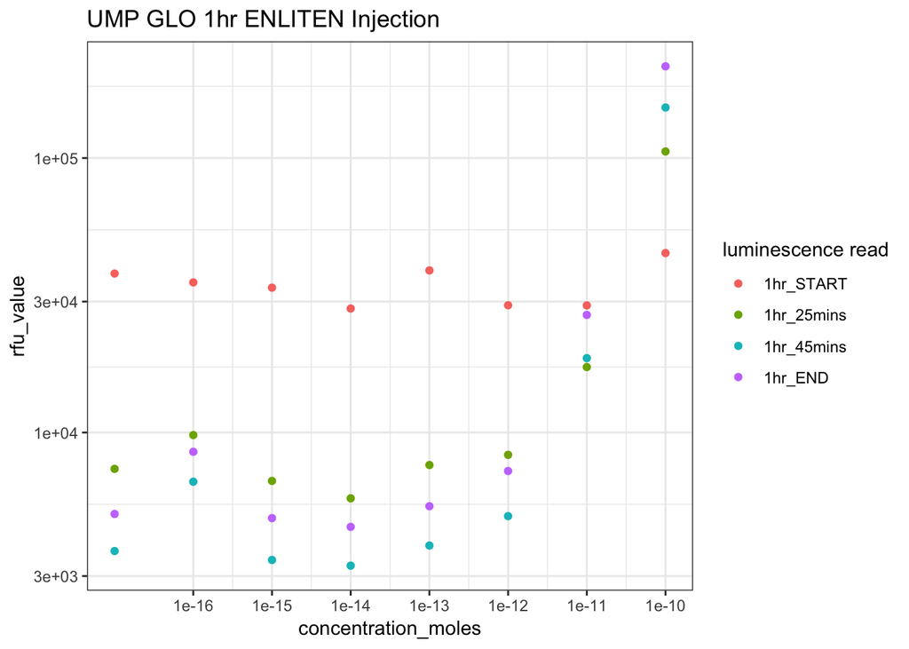

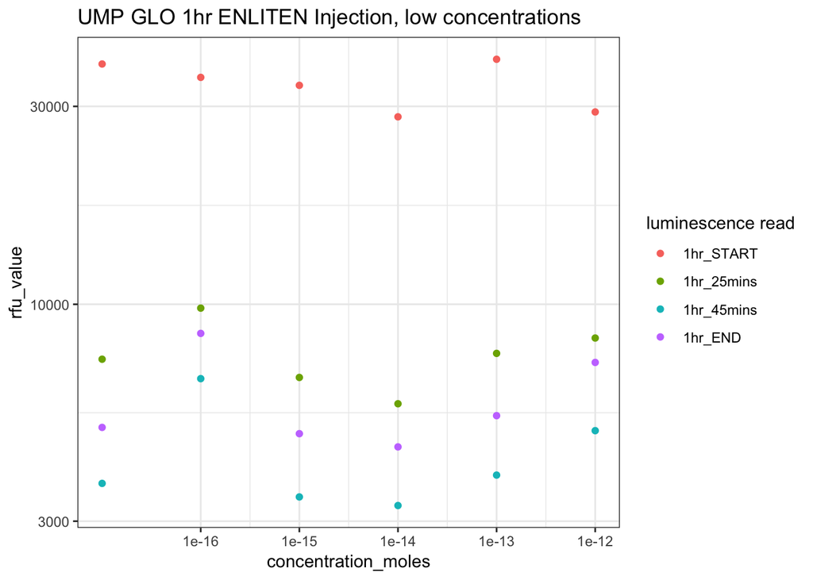

## AMP GLO no Kinase GLO 1hr incubation

- 1X NEBuffer 2.1 was added instead of Kinase GLO (ie 1mL 1X NEBuffer 2.1 + 10uL Reagent II)
- AMP GLO without kinase GLO was added to AMP standards and read was taken. This is the 1hr_START read.
- Read was taken during room temperature incubation at 25 minutes and 45 minutes
- At 50 minutes, injection read was performed - starting with highest concentration, ENLITEN was injected, a 2s delay occured and a 10s read was taken. This is the 1hr_END read.
- 0 point removed for logistic regression plotted on log scale

### Conclusions

Oooo this looks promising! Need more replicates, but the 1e-14 and 1e-15 is above the 0. In any case, it appears that ENLITEN can work with ADP -> ATP, but that with the AMP and UMP, the ATP is being depleted to reduce signal when ENLITEN is finally added.

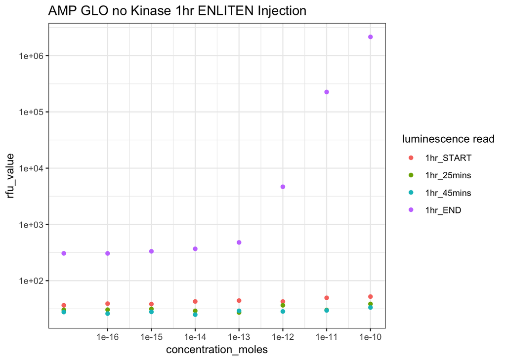

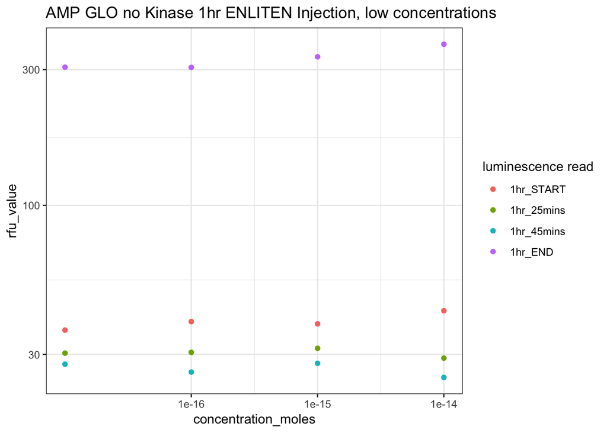

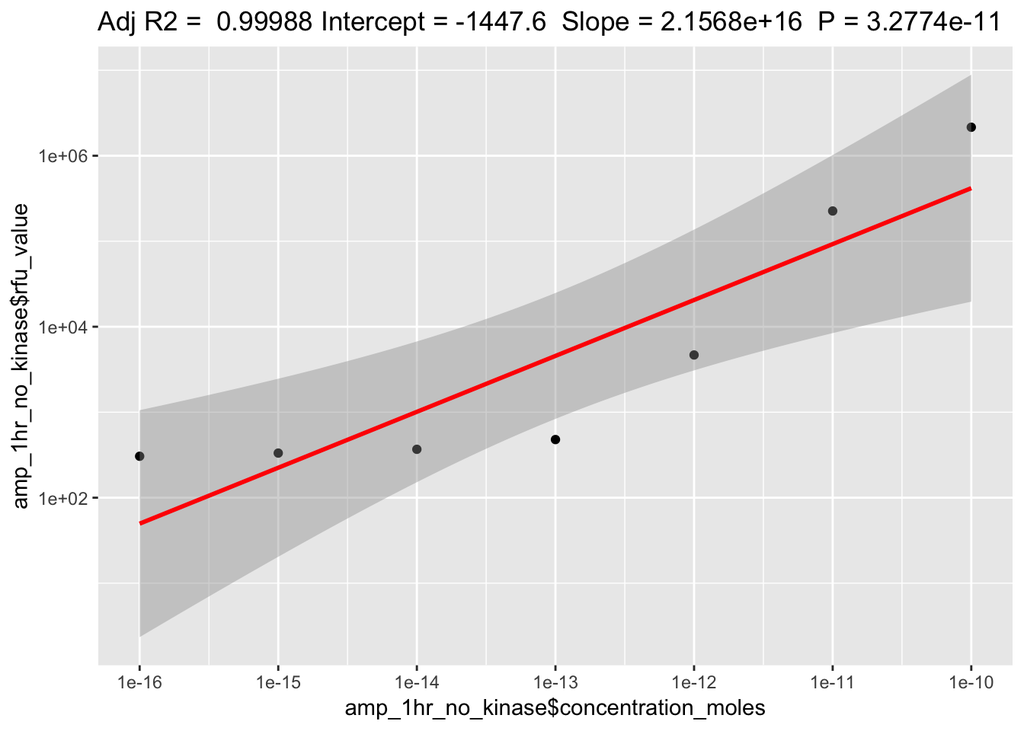

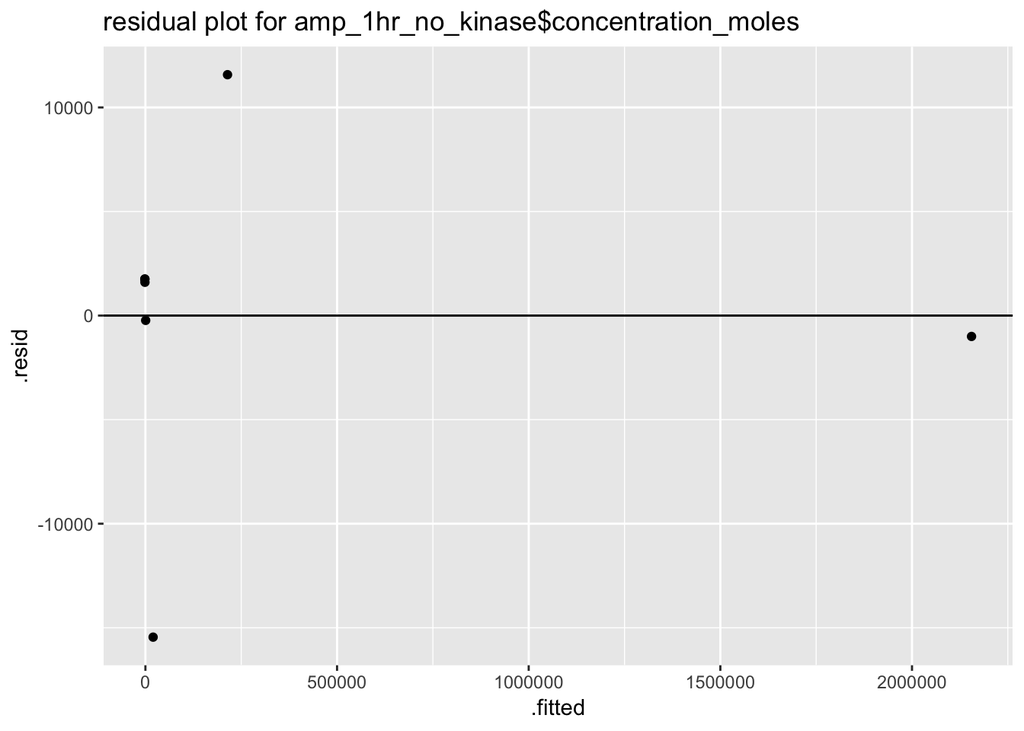

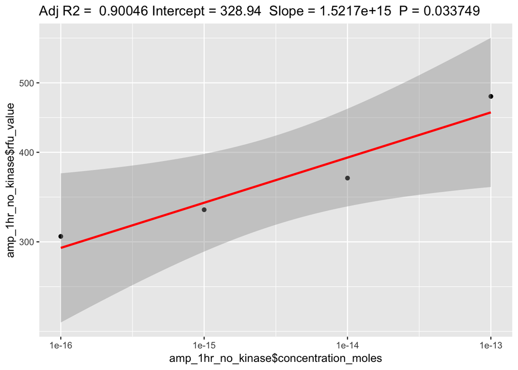

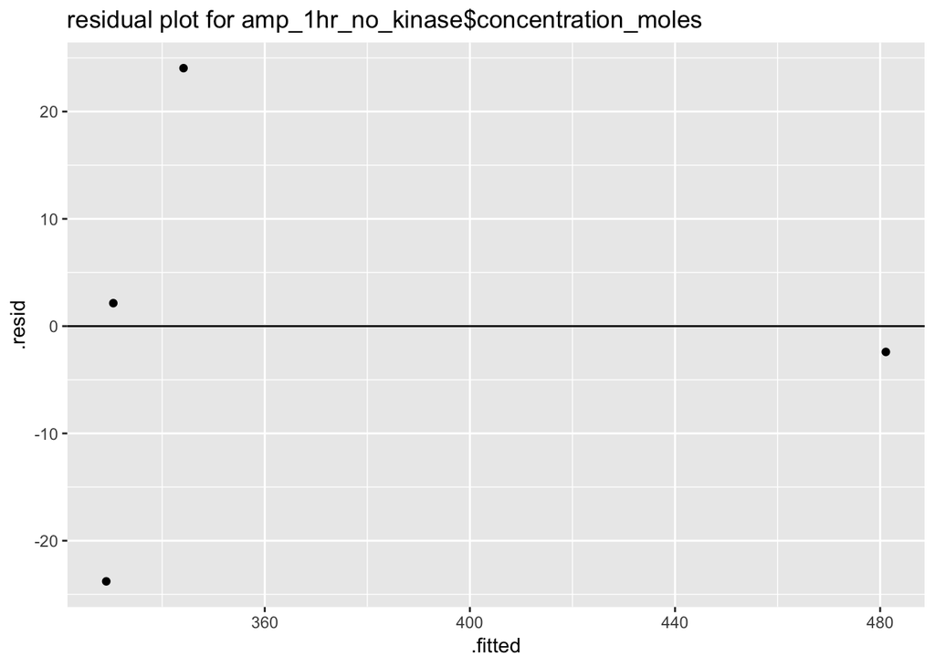